# StatsWales CYP Counselling

Aura Frizzati

2024-04-28

```r
## Load relevant libraries
library(statswalesr) ## import data from StatsWales
library(tidyverse)  ## data wrangling
library(sf)          ## choropleth maps
library(patchwork)  ## compose ggplots
library(gt) ## well formatted tables
```

# **Counselling for children and young people in StatsWales**

Information on provision of independent counselling services for children and young people aged between 11 and 18 and pupils in Year 6 of primary school. (https://statswales.gov.wales/Catalogue/Education-and-Skills/Schools-and-Teachers/Counselling-for-Children-and-Young-People)

- **SCHS0501**: the number of children and young people who have **attended counselling**. This data can be split by year, area, ethnicity and gender.
- **SCHS0502**: the number of children and young people who have **attended more than one counselling episode**. This data can be split by year, area, episode and gender.
- **SCHS0504**: the number of children and young people who have **received counselling by school year age**. This data can be split by year, area, school year age and gender.
- **POPU0006**: Wales population estimates by Year, Age and LA (https://statswales.gov.wales/Catalogue/Population-and-Migration/Population/Estimates/Local-Authority/populationestimates-by-localauthority-region-age)

```r
## import local data downloaded form StatsWales using statswalesr library
SCHS0501 <-readRDS(file = "StatsWales_data/SCHS0501.rds")
SCHS0502 <-readRDS(file = "StatsWales_data/SCHS0502.rds")
SCHS0504 <-readRDS(file = "StatsWales_data/SCHS0504.rds")
POPU0006 <-readRDS(file = "StatsWales_data/POPU0006.rds")
```

The code below has been used to create the Figures used in the report

### Figure 1:

```r
Table_Figure1a <-
  SCHS0501 |>
  mutate(Year = stringr::str_replace(Year_ItemName_ENG,"-","/"))  |>
  filter(Data >=0 &
           Area_ItemName_ENG == "Wales" &
           Ethnicity_ItemName_ENG == "Total" &
           SexatBirth_ItemName_ENG == "Total" )|>
  group_by(Year) |>
  summarise(Data = sum(Data, na.rm = T))


Table_Figure1a |>
  rename(`Tot CYP receiving counselling` = Data) |>
  gt::gt() |> tab_options(table.font.size = 12)
```

| Year | Tot CYP receiving counselling |
| --- | --- |
| 2013/14 | 10536 |
| 2014/15 | 11568 |
| 2015/16 | 11337 |
| 2016/17 | 11559 |
| 2017/18 | 11364 |
| 2018/19 | 11754 |
| 2019/20 | 9633 |
| 2020/21 | 10545 |
| 2021/22 | 12411 |
| 2022/23 | 12342 |

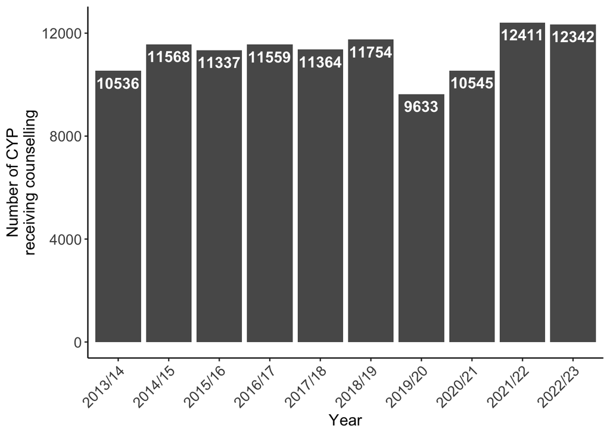

```r
Figure1a <-
  Table_Figure1a |>
  ggplot(aes(x=Year,y=Data)) +
  geom_bar(stat="identity") +
  theme(
    panel.grid.major = element_blank(),
    panel.grid.minor = element_blank(),
    panel.background = element_blank(),
    axis.line = element_line(colour = "black")
    ,axis.text.y=element_text(size=12),
    axis.title=element_text(size=13)
    ,axis.text.x=element_text(size=12,angle = 45, vjust = 1, hjust=1)) +
  labs(y="Number of CYP\nreceiving counselling") +
  geom_text(aes(label=Data), vjust=1.6, color="white", fontface = "bold", size=4.5)


Figure1a
```

```r
Table_Figure1b <-
  SCHS0501 |>
  mutate(Year = stringr::str_replace(Year_ItemName_ENG,"-","/"))  |>
  filter(Data >=0 &
           Area_ItemName_ENG == "Wales" &
           Ethnicity_ItemName_ENG == "Total" &
           SexatBirth_ItemName_ENG != "Total" )|>
  group_by(Year) |>
  mutate(TotDataByYear = sum(Data, na.rm = T)) |>
  ungroup(Year) |>
  group_by(Year,SexatBirth_ItemName_ENG)|>
  summarise(pct= round((Data/TotDataByYear) * 100,1)) |>
  mutate(SexatBirth_ItemName_ENG =
           if_else(SexatBirth_ItemName_ENG == "Female (sex at birth)"
                   , "Female","Male")) |>
  ungroup()

Table_Figure1b |>
  pivot_wider(values_from = pct, names_from = SexatBirth_ItemName_ENG) |>
  gt::gt() |>
  tab_options(table.font.size = 12)
```

| Year | Female | Male |
| --- | --- | --- |
| 2013/14 | 64.1 | 35.9 |
| 2014/15 | 63.7 | 36.3 |
| 2015/16 | 62.8 | 37.2 |
| 2016/17 | 62.7 | 37.3 |
| 2017/18 | 62.6 | 37.4 |
| 2018/19 | 63.2 | 36.8 |
| 2019/20 | 65.9 | 34.1 |
| 2020/21 | 67.5 | 32.5 |
| 2021/22 | 68.9 | 31.1 |
| 2022/23 | 67.6 | 32.4 |

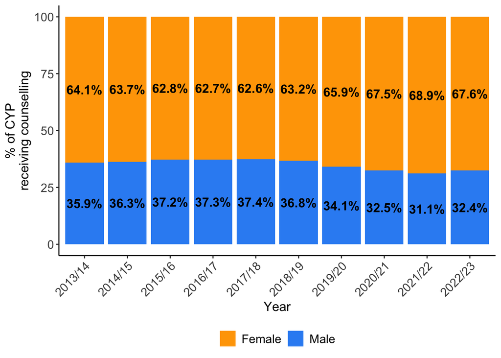

```r
Figure1b <-
  Table_Figure1b |>
  ggplot(aes(x=Year,y=pct, fill = SexatBirth_ItemName_ENG))  +
  geom_bar(stat="identity") +
  geom_text(aes(label=paste0(pct,"%")),
            position=position_stack(vjust=0.5), fontface = "bold", size=4.5)+
 # scale_x_continuous("Year", labels = as.character(2013:2022), breaks = 2013:2022)+
  theme(
    panel.grid.major = element_blank(),
    panel.grid.minor = element_blank(),
    panel.background = element_blank(),
    axis.line = element_line(colour = "black")
    ,legend.position="bottom"
    ,legend.title = element_blank()
    ,legend.text=element_text(size=12)
    ,axis.text.y=element_text(size=12),
    axis.title=element_text(size=13)
    ,axis.text.x=element_text(size=12,angle = 45, vjust = 1, hjust=1)) +
  labs(y="% of CYP\nreceiving counselling")+
scale_fill_manual(values=c("orange", "#3390F3"))

Figure1b
```

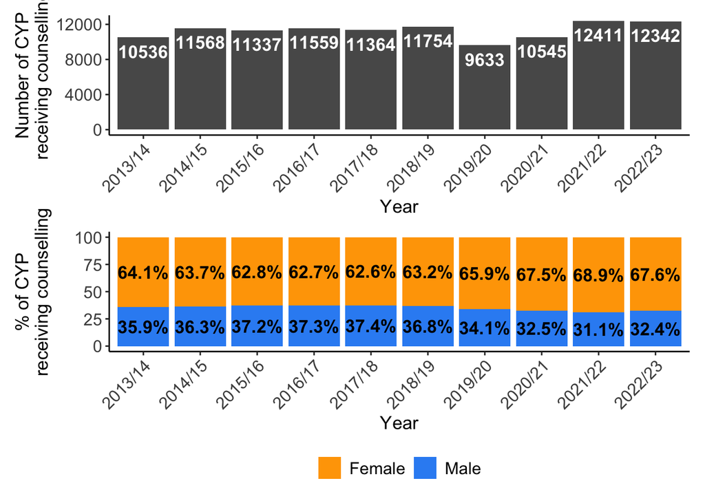

```r
Figure1 <- Figure1a/ Figure1b
Figure1
```

```r
## produce output figure
png("output/Figure1.png", width = 700, height = 400)
print(Figure1)
dev.off()
```

### Figure 2

#### Figure 2: Number of CYP who received counselling in Wales in 2022/23 by School Year and Gender

```r
vector_schoolyeargroups <-
  c("Year 6","Year 7","Year 8","Year 9","Year 10"
    ,"Year 11","Year 12","Year 13")

Table_Figure2 <-
    SCHS0504 |>
  filter(Area_ItemName_ENG == "Wales" &
           SexatBirth_ItemName_ENG != "Total" &
           Schoolyearagegroup_ItemName_ENG %in% vector_schoolyeargroups &
           Year_ItemName_ENG == "2022-23"&
           Schoolyearagegroup_Hierarchy == "1") |>
  group_by(Schoolyearagegroup_ItemName_ENG, SexatBirth_ItemName_ENG) |>
  mutate(
    SexatBirth_ItemName_ENG =
      if_else(SexatBirth_ItemName_ENG == "Female (sex at birth)",
              "Female", "Male")
    ,Schoolyearagegroup_ItemName_ENG=as.factor(Schoolyearagegroup_ItemName_ENG)
    ,Schoolyearagegroup_ItemName_ENG=
      forcats::fct_relevel(Schoolyearagegroup_ItemName_ENG,vector_schoolyeargroups)) |>
  summarise(Data = sum(Data)) |>
  ungroup() |>
  tidyr::pivot_wider(names_from = SexatBirth_ItemName_ENG, values_from= Data) |>
  mutate(
    Total = Female + Male
    ,TotalFemale = sum(Female)
    ,TotalMale = sum(Male)
    ,PercentFemale = round(100*Female/TotalFemale,1)
    ,PercentMale = round(100*Male/TotalMale,1)
  )

Table_Figure2  |>
  rename(TotByYear = Total,
         `School Year` = Schoolyearagegroup_ItemName_ENG) |>
  gt::gt() |>
  tab_options(table.font.size = 12)
```

| School Year | Female | Male | TotByYear | TotalFemale | TotalMale | PercentFemale | PercentMale |
| --- | --- | --- | --- | --- | --- | --- | --- |
| Year 6 | 297 | 306 | 603 | 7659 | 3531 | 3.9 | 8.7 |
| Year 7 | 867 | 549 | 1416 | 7659 | 3531 | 11.3 | 15.5 |
| Year 8 | 1341 | 645 | 1986 | 7659 | 3531 | 17.5 | 18.3 |
| Year 9 | 1593 | 603 | 2196 | 7659 | 3531 | 20.8 | 17.1 |
| Year 10 | 1647 | 630 | 2277 | 7659 | 3531 | 21.5 | 17.8 |
| Year 11 | 1347 | 525 | 1872 | 7659 | 3531 | 17.6 | 14.9 |
| Year 12 | 333 | 162 | 495 | 7659 | 3531 | 4.3 | 4.6 |
| Year 13 | 234 | 111 | 345 | 7659 | 3531 | 3.1 | 3.1 |

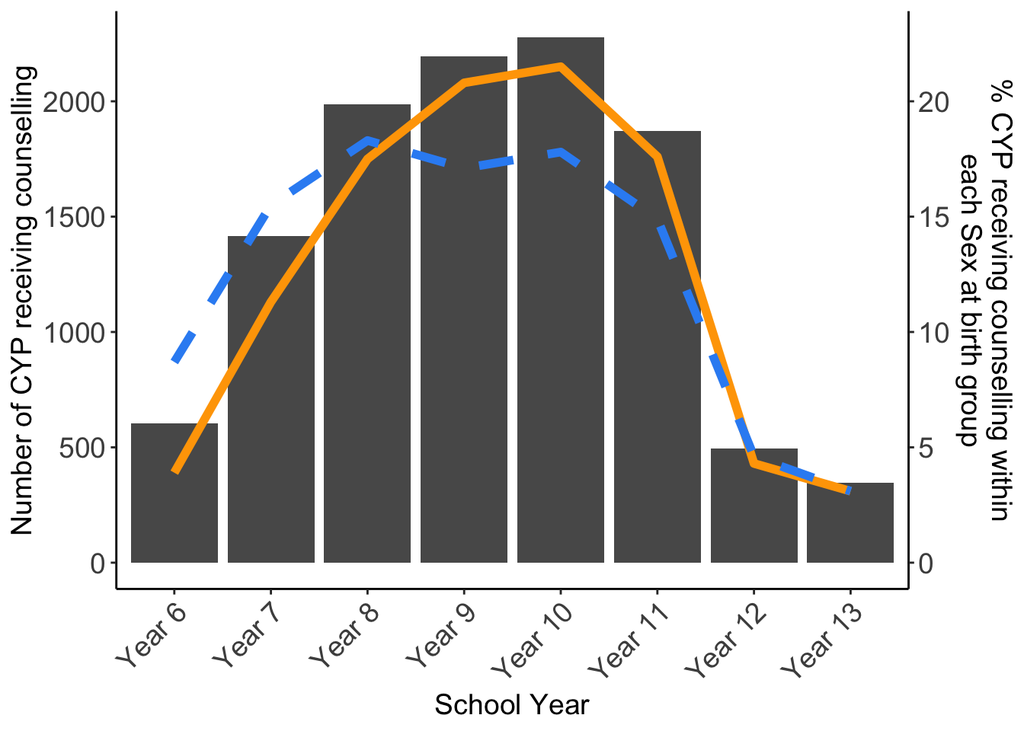

```r
Figure2 <-
  Table_Figure2 |>
  ggplot(aes(x = Schoolyearagegroup_ItemName_ENG)) +
  geom_bar(aes(y = Total), stat = "identity")+
  geom_line(aes(y = 100*PercentFemale, group = 1),
            stat = "identity", colour = "orange",size = 2)+
  geom_line(aes(y = 100*PercentMale, group = 1),
            stat = "identity", colour = "#3390F3",linetype = "dashed", size = 2)+
  scale_y_continuous(sec.axis=sec_axis(~.*0.01,name="% CYP receiving counselling within\neach Sex at birth group")) +
  theme(
    panel.grid.major = element_blank(),
    panel.grid.minor = element_blank(),
    panel.background = element_blank(),
    axis.line = element_line(colour = "black")
    ,axis.text.y=element_text(size=14)
    ,axis.text.x=element_text(size=14,angle = 45, vjust = 1, hjust=1),
    axis.title=element_text(size=14)) +
  labs(x="School Year", y="Number of CYP receiving counselling")

Figure2
```

```r
## produce output figure
png("output/Figure2.png", width = 700, height = 400)
print(Figure2)
dev.off()
```

### Figure 3:

```r
## download LA boundaries
GeoJSON_url_2022<-"https://services1.arcgis.com/ESMARspQHYMw9BZ9/arcgis/rest/services/Local_Authority_Districts_December_2022_UK_BUC_V2/FeatureServer/0/query?outFields=*&where=1%3D1&f=geojson"
lad_boundaries_2022 <- read_sf(GeoJSON_url_2022)
```

#### Figure 3a: Rate of CYP per 100 of resident 10 to 18 year olds receiving counselling for year 2022/23 by Local Authority

```r
## Extract relevant age band of CYP (10-18 years old) from the census population data and gorup by LA for mid-year 2022
POPU0006_10_18years_byLA_2022<-
  POPU0006 |>
  filter(Year_ItemName_ENG == "Mid-year 2022" &
           Sex_ItemName_ENG =="Persons" &
           !(Area_ItemName_ENG %in% c("Wales","North Wales",
                                      "Mid and South West Wales","South East Wales")) &
           ## no need to keep age band 90-99 (which is coded only as an aggregated class)
           (nchar(Age_Code)<4)) |>
  mutate(Age = as.integer(Age_Code)) |>
  filter(Age >= 10 & Age <= 18) |>
  group_by(Year_ItemName_ENG,Area_ItemName_ENG,Area_AltCode1)|>
  summarise(tot= sum(Data, na.rm = T)) |>
  ungroup()


POPU0006_10_18years_byLA_2022 <-
   ### Merge "Isle of Anglesey" and "Gwynedd"
  POPU0006_10_18years_byLA_2022 |>
  bind_rows(data.frame(
    Year_ItemName_ENG = "Mid-year 2022"
    ,Area_ItemName_ENG = "Isle of Anglesey and Gwynedd"
    ,Area_AltCode1 = "W06000007"
    ,tot =
      POPU0006_10_18years_byLA_2022 |>
      filter(Area_AltCode1 == "W06000001") |>
      select(tot) |> pull() +
      POPU0006_10_18years_byLA_2022 |>
      filter(Area_AltCode1 == "W06000002") |>
      select(tot) |> pull()
  )) |>
  ### Remove "Isle of Anglesey" and "Gwynedd"
  filter(Area_AltCode1 != "W06000001" & Area_AltCode1 != "W06000002")

## extract CYP receiving counselling in 2022/23 and group by LA
SCHS0501_byLA_202223 <-
  SCHS0501 |>
  filter(Data >=0 & Area_ItemName_ENG != "Wales" &
           Ethnicity_ItemName_ENG == "Total" &
           SexatBirth_ItemName_ENG == "Total" &
           Year_ItemName_ENG=="2022-23")|>
  group_by(Year_ItemName_ENG,Area_ItemName_ENG,Area_AltCode1)|>
  summarise(tot= sum(Data, na.rm = T))

## join the two tables and calculate rate of CYP receiving counselling per 100 CYP population by LA for 2022/23
SCHS0501_byLA_202223_per100pop <-
  SCHS0501_byLA_202223 |>
  inner_join(
    POPU0006_10_18years_byLA_2022 |>
      select(Area_AltCode1,tot) |> rename(tot_pop =tot)
    ,by = "Area_AltCode1") |>
  mutate(N_per_100 = round(100*tot/tot_pop,1))

Table_Figure3a <-
  SCHS0501_byLA_202223_per100pop |>
  ## Split "Isle of Anglesey" and "Gwynedd"
  bind_rows(
    SCHS0501_byLA_202223_per100pop |>
      filter(Area_AltCode1 =="W06000007") |>
      mutate(
        Area_AltCode1 = "W06000001"
        ,Area_ItemName_ENG = "Isle of Anglesey")) |>
  bind_rows(
    SCHS0501_byLA_202223_per100pop |>
      filter(Area_AltCode1 =="W06000007") |>
      mutate(
        Area_AltCode1 = "W06000002"
        ,Area_ItemName_ENG = "Gwynedd")) |>
  ## remove "Isle of Anglesey and Gwynedd"
  filter(Area_AltCode1 !="W06000007") |>
  ungroup()


Table_Figure3a |>
  select(Area_ItemName_ENG,N_per_100) |>
  rename(`Local Authority` = Area_ItemName_ENG, Rate = N_per_100) |>
  arrange(desc(Rate)) |>
  gt::gt() |>
  tab_options(table.font.size = 12)
```

| Local Authority | Rate |
| --- | --- |
| Carmarthenshire | 7.3 |
| Powys | 6.8 |
| Ceredigion | 6.2 |
| Pembrokeshire | 5.8 |
| Rhondda Cynon Taf | 5.6 |
| Merthyr Tydfil | 5.3 |
| Swansea | 5.1 |
| Neath Port Talbot | 4.3 |
| Torfaen | 4.3 |
| Flintshire | 3.6 |
| Wrexham | 3.5 |
| Vale of Glamorgan | 3.1 |
| Isle of Anglesey | 3.1 |
| Gwynedd | 3.1 |
| Conwy | 2.9 |
| Denbighshire | 2.9 |
| Blaenau Gwent | 2.6 |
| Caerphilly | 2.6 |
| Monmouthshire | 2.5 |
| Bridgend | 2.0 |
| Cardiff | 1.5 |
| Newport | 1.2 |

```r
Wales_national_rate <-round(100*sum(SCHS0501_byLA_202223_per100pop$tot)/sum(SCHS0501_byLA_202223_per100pop$tot_pop),1)

print(paste0("Wales national rate: ", Wales_national_rate, " per 100 residents 10-18 years-old"))
```

```
## [1] "Wales national rate: 3.8 per 100 residents 10-18 years-old"
```

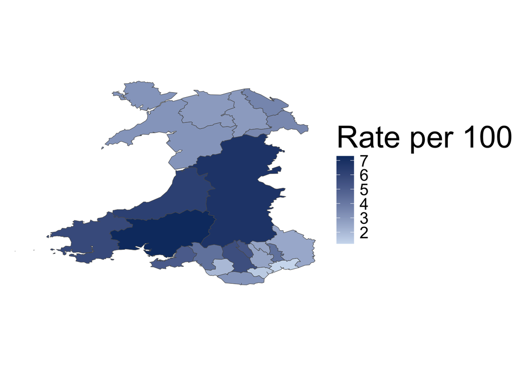

```r
Figure3a <-
  Table_Figure3a |>
  left_join(
    lad_boundaries_2022,
    by = c("Area_AltCode1" = "LAD22CD")
  ) |>
  rename(`Rate per 100`= N_per_100) |>
  ggplot(aes(fill = `Rate per 100`)) +
  geom_sf(aes(geometry = geometry)) + # plot all local authority geometries
  # removes unnecessary background grid and axes
  theme_void()+
  scale_fill_gradient(low = "#CFDDEF", high = "#0F396F")+
  theme(
    legend.text = element_text(size = 16),
    legend.title = element_text(size = 30)
    )

Figure3a
```

#### Figure 3b: Average number of waiting weeks for counselling sessions by LA for year 2022/23

```r
Table_Figure3b <-
  SCHS0502 |>
  filter(
    Year_Code == "202223" &
      Episodes_ItemName_ENG == "Average number of weeks waiting to attend first counselling session?" &
      SexatBirth_ItemName_ENG == "Total") |>

  ## Split "Isle of Anglesey" and "Gwynedd"
  bind_rows(
    SCHS0502 |>
      filter(Year_Code == "202223" &
               Episodes_ItemName_ENG == "Average number of weeks waiting to attend first counselling session?" &
               SexatBirth_ItemName_ENG == "Total" &
               Area_AltCode1 =="W06000007") |>
      mutate(
        Area_AltCode1 = "W06000001"
        ,Area_ItemName_ENG = "Isle of Anglesey")) |>
  bind_rows(
    SCHS0502 |>
      filter(Year_Code == "202223" &
               Episodes_ItemName_ENG == "Average number of weeks waiting to attend first counselling session?" &
               SexatBirth_ItemName_ENG == "Total" &
               Area_AltCode1 =="W06000007") |>
              mutate(
                Area_AltCode1 = "W06000002"
                ,Area_ItemName_ENG = "Gwynedd")) |>

  ## Add "Conwy" entry as NA
  bind_rows(
    SCHS0502 |>
      filter(Year_Code == "202223" &
               Episodes_ItemName_ENG == "Average number of weeks waiting to attend first counselling session?" &
               SexatBirth_ItemName_ENG == "Total" &
               Area_AltCode1 =="W06000007")  |>
              mutate(
                Area_AltCode1 = "W06000003"
                ,Area_ItemName_ENG = "Conwy"
                ,Data = NA)) |>
  rename(`Average waiting weeks`= Data)


Table_Figure3b |>
  select(Area_ItemName_ENG,`Average waiting weeks`) |>
  rename(`Local Authority` = Area_ItemName_ENG) |>
  arrange(desc(`Average waiting weeks`)) |>
  gt::gt() |>
  tab_options(table.font.size = 12)
```

| Local Authority | Average waiting weeks |
| --- | --- |
| Vale of Glamorgan | 17.36 |
| Blaenau Gwent | 13.00 |
| Monmouthshire | 12.00 |
| Denbighshire | 9.11 |
| Flintshire | 8.44 |
| Wrexham | 8.40 |
| Caerphilly | 7.80 |
| Newport | 7.00 |
| Torfaen | 6.75 |
| Cardiff | 6.29 |
| Powys | 5.90 |
| Neath Port Talbot | 5.70 |
| Carmarthenshire | 4.50 |
| Swansea | 4.00 |
| Isle of Anglesey and Gwynedd | 3.95 |
| Isle of Anglesey | 3.95 |
| Gwynedd | 3.95 |
| Pembrokeshire | 2.00 |
| Merthyr Tydfil | 2.00 |
| Ceredigion | 1.75 |
| Bridgend | 1.58 |
| Rhondda Cynon Taf | 1.00 |
| Conwy | NA |

```r
Wales_national_avgwaitingweeks <-
  SCHS0502 |>
  filter(
    Year_Code == "202223" &
      Episodes_ItemName_ENG == "Average number of weeks waiting to attend first counselling session?" &
      SexatBirth_ItemName_ENG == "Total") |> summarise(`Wales average waiting weeks` = mean(Data,na.rm=T))
Wales_national_avgwaitingweeks
```

```
##   Wales average waiting weeks
## 1                      6.4265
```

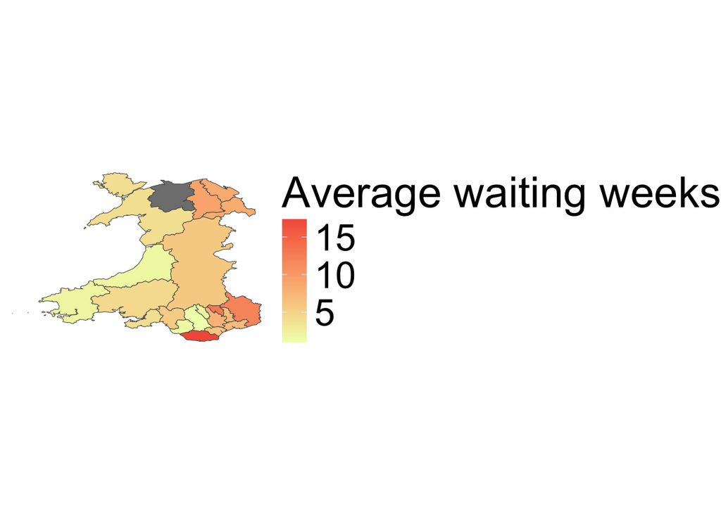

```r
Figure3b <-
  Table_Figure3b |>
  left_join(
    lad_boundaries_2022,
    by = c("Area_AltCode1" = "LAD22CD")
  ) |>
  ggplot(aes(fill = `Average waiting weeks`)) +
  geom_sf(aes(geometry = geometry)) + # plot all local authority geometries
  # removes unnecessary background grid and axes
  theme_void()+
  scale_fill_gradient(low = "#EFFEB7", high = "#F45E49")+
  theme(
    legend.text = element_text(size = 26),
    legend.title = element_text(size = 30))

Figure3b
```

```r
Fig3_part1 <- Figure3a + Figure3b
#Fig3_part1
```

```r
## produce output figure
png("output/Fig3_part1.png", width = 1500, height = 1000)
print(Fig3_part1)
dev.off()
```

#### Figure 3c: Average number of counselling sessions per CYP by LA for year 2022/23

```r
Table_Figure3c <-
    SCHS0502 |>
  filter(
    Year_Code == "202223" &
      Episodes_ItemName_ENG == "Average number of sessions (calculated)" &
      SexatBirth_ItemName_ENG == "Total") |>

  ## Split "Isle of Anglesey" and "Gwynedd"
  bind_rows(
    SCHS0502 |>
      filter(Year_Code == "202223" &
               Episodes_ItemName_ENG == "Average number of sessions (calculated)" &
               SexatBirth_ItemName_ENG == "Total" &
               Area_AltCode1 =="W06000007") |>
      mutate(
        Area_AltCode1 = "W06000001"
        ,Area_ItemName_ENG = "Isle of Anglesey")) |>
  bind_rows(
    SCHS0502 |>
      filter(Year_Code == "202223" &
               Episodes_ItemName_ENG == "Average number of sessions (calculated)" &
               SexatBirth_ItemName_ENG == "Total" &
               Area_AltCode1 =="W06000007") |>
              mutate(
                Area_AltCode1 = "W06000002"
                ,Area_ItemName_ENG = "Gwynedd")) |>
  filter(Area_AltCode1 !="W06000007") |>
  rename(`Average sessions`= Data)

Table_Figure3c |>
  select(Area_ItemName_ENG,`Average sessions`) |>
  rename(`Local Authority` = Area_ItemName_ENG) |>
  arrange(desc(`Average sessions`)) |>
  gt::gt()  |>
  tab_options(table.font.size = 12)
```

| Local Authority | Average sessions |
| --- | --- |
| Powys | 8.344907 |
| Monmouthshire | 8.158798 |
| Torfaen | 7.240741 |
| Wrexham | 7.077973 |
| Blaenau Gwent | 6.840000 |
| Bridgend | 6.605178 |
| Denbighshire | 6.562290 |
| Carmarthenshire | 6.392907 |
| Isle of Anglesey | 6.227826 |
| Gwynedd | 6.227826 |
| Wales | 6.094304 |
| Conwy | 6.049383 |
| Newport | 5.976959 |
| Neath Port Talbot | 5.917933 |
| Pembrokeshire | 5.881081 |
| Flintshire | 5.857143 |
| Rhondda Cynon Taf | 5.630844 |
| Caerphilly | 5.615542 |
| Ceredigion | 5.420655 |
| Cardiff | 5.411765 |
| Swansea | 5.077840 |
| Vale of Glamorgan | 4.874730 |
| Merthyr Tydfil | 4.621212 |

```r
Wales_avg_N_sessions <-
  SCHS0502 |>
  filter(
    Year_Code == "202223" &
      Episodes_ItemName_ENG == "Average number of sessions (calculated)" &
      SexatBirth_ItemName_ENG == "Total") |> summarise(Wales_avg_N_sessions = mean(Data,na.rm=T))

Wales_avg_N_sessions
```

```
##   Wales_avg_N_sessions
## 1             6.176364
```

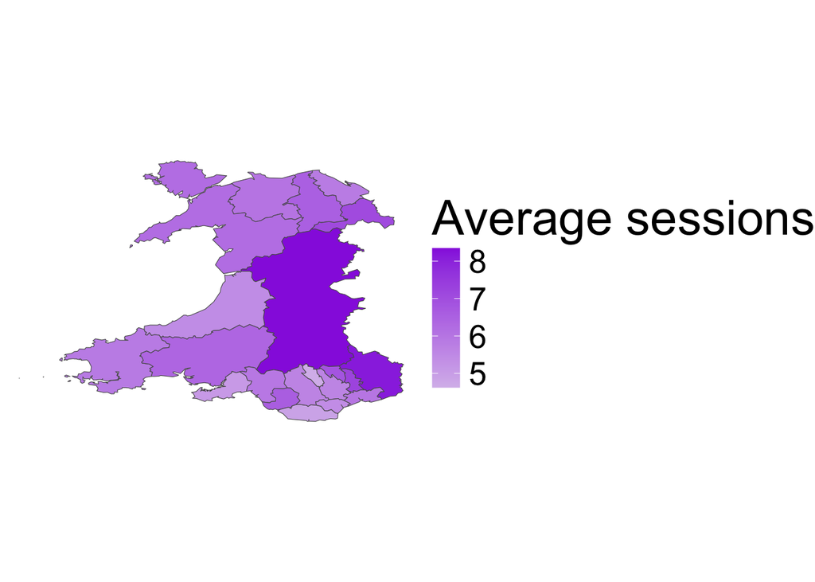

```r
Figure3c <-
  Table_Figure3c |>
  left_join(
    lad_boundaries_2022,
    by = c("Area_AltCode1" = "LAD22CD")
  ) |>
  ggplot(aes(fill = `Average sessions`)) +
  geom_sf(aes(geometry = geometry)) + # plot all local authority geometries
  # removes unnecessary background grid and axes
  theme_void()+
  scale_fill_gradient(low = "#D8BDEC", high = "#9733E0")+
  theme(
    legend.text = element_text(size = 20),
    legend.title = element_text(size = 30))

Figure3c
```

#### Figure 3d: Average improvement score for counselling sessions by LA for year 2022/23

```r
Table_Figure3d <-
    SCHS0502 |>
  filter(
    Year_Code == "202223" &
      Episodes_ItemName_ENG == "Average Improvement" &
      SexatBirth_ItemName_ENG == "Total") |>

  ## Split "Isle of Anglesey" and "Gwynedd"
  bind_rows(
    SCHS0502 |>
      filter(Year_Code == "202223" &
               Episodes_ItemName_ENG == "Average Improvement" &
               SexatBirth_ItemName_ENG == "Total" &
               Area_AltCode1 =="W06000007") |>
      mutate(
        Area_AltCode1 = "W06000001"
        ,Area_ItemName_ENG = "Isle of Anglesey")) |>
  bind_rows(
    SCHS0502 |>
      filter(Year_Code == "202223" &
               Episodes_ItemName_ENG == "Average Improvement" &
               SexatBirth_ItemName_ENG == "Total" &
               Area_AltCode1 =="W06000007") |>
              mutate(
                Area_AltCode1 = "W06000002"
                ,Area_ItemName_ENG = "Gwynedd")) |>
  filter(Area_AltCode1 !="W06000007") |>
  rename(`Average improvement`= Data)

Table_Figure3d |>
  select(Area_ItemName_ENG,`Average improvement`) |>
  rename(`Local Authority` = Area_ItemName_ENG) |>
  arrange(desc(`Average improvement`)) |>
  gt::gt()  |>
  tab_options(table.font.size = 12)
```

| Local Authority | Average improvement |
| --- | --- |
| Neath Port Talbot | 9.600000 |
| Rhondda Cynon Taf | 8.510000 |
| Denbighshire | 7.620000 |
| Pembrokeshire | 7.500000 |
| Blaenau Gwent | 7.500000 |
| Newport | 7.450000 |
| Monmouthshire | 7.350000 |
| Wrexham | 6.500000 |
| Merthyr Tydfil | 6.500000 |
| Bridgend | 6.200000 |
| Wales | 6.080449 |
| Flintshire | 6.050000 |
| Swansea | 5.800000 |
| Caerphilly | 5.500000 |
| Torfaen | 5.500000 |
| Powys | 5.170000 |
| Vale of Glamorgan | 5.130000 |
| Carmarthenshire | 4.920000 |
| Cardiff | 4.630000 |
| Conwy | 4.460000 |
| Ceredigion | 4.390000 |
| Isle of Anglesey | 2.000000 |
| Gwynedd | 2.000000 |

```r
Wales_avg_improvement <-
  SCHS0502 |>
  filter(
    Year_Code == "202223" &
      Episodes_ItemName_ENG == "Average Improvement" &
      SexatBirth_ItemName_ENG == "Total") |> summarise(Wales_avg_improvement = mean(Data,na.rm=T))

Wales_avg_improvement
```

```
##   Wales_avg_improvement
## 1              6.107293
```

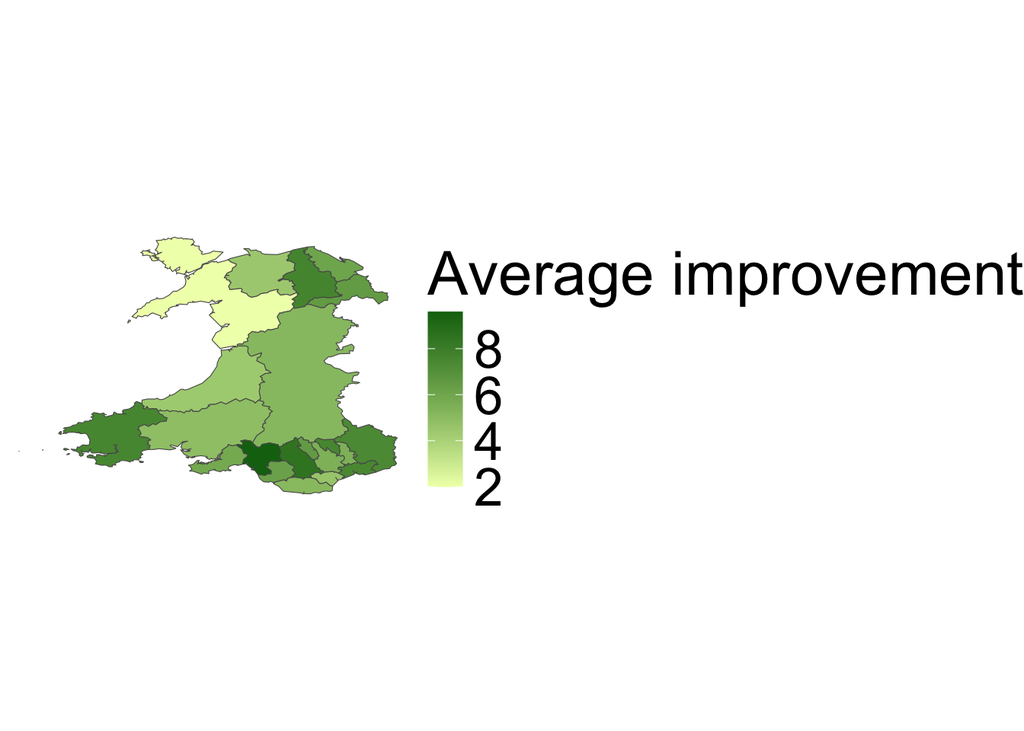

```r
Figure3d <-
  Table_Figure3d |>
  left_join(
    lad_boundaries_2022,
    by = c("Area_AltCode1" = "LAD22CD")
  ) |>
  ggplot(aes(fill = `Average improvement`)) + # create a ggplot object and
  # change its fill colour according to median_age
  geom_sf(aes(geometry = geometry)) + # plot all local authority geometries
  #scale_fill_viridis("Average Waiting Weeks") +
  # removes unnecessary background grid and axes
  theme_void()+
  scale_fill_gradient(low = "#EFFEB7", high = "#0F6F11")+
  theme(
    legend.text = element_text(size = 26),
    legend.title = element_text(size = 30))

Figure3d
```

```r
Fig3_part2 <- Figure3c + Figure3d
#Fig3_part2
```

```r
## produce output figure
png("output/Fig3_part2.png", width = 1500, height = 1000)
print(Fig3_part2)
dev.off()
```